# The Political Economy of Public Banks

Electoral Effects of Savings Banks in German Subnational Politics - The Case of Bavaria

Jonas Markgraf & Malte Berneaud-Kötz Hertie School of Governance

## Abstract

This paper aims to **estimate the effect of board membership in German *Sparkassen* (public savings banks) on politicians’ success in local elections**. For this purpose, we exploit the fact that not all locally elected political leaders in Germany are board members in savings banks and compare electoral performance of politicians with and without participation in savings bank’s Board of Directors. The paper contributes to the Public Economics literature on *electoral credit cycles* that argues that public banks increase lending in years preceeding elections and to the Political Science debate on the *incumbency advantage* that politicians appear to enjoy. It will be analyzed if board membership of incumbents is a mediating factor for the *incumbency effect*. As part of the research project, we compile a novel, largely hand-collected panel dataset on the boardroom composition of German savings banks with detailed information on board member profiles, along with data on municipal electoral results in Bavaria covering 2,099 municipalities and 79 savings banks over the period from 2006 to 2015.[^1]

## Background

### The Financial Crisis

The collapse of large the US bank Lehman Brothers in 2008 and the global financial crisis brought banks to the attention of the general public and raised academic interest in the relation between banking and politics. However: Public banks, that means the role of politicians *within* banks, are strikingly neglected by the Political Economy literature. This comes as a surprise as they constitute an essential part of the European bank-based financial system, played a central role during the financial crisis[^2] and provide a highly interesting case for Political Economists to study the effects of politicized corporate governance.

### Politicized Sparkassen!

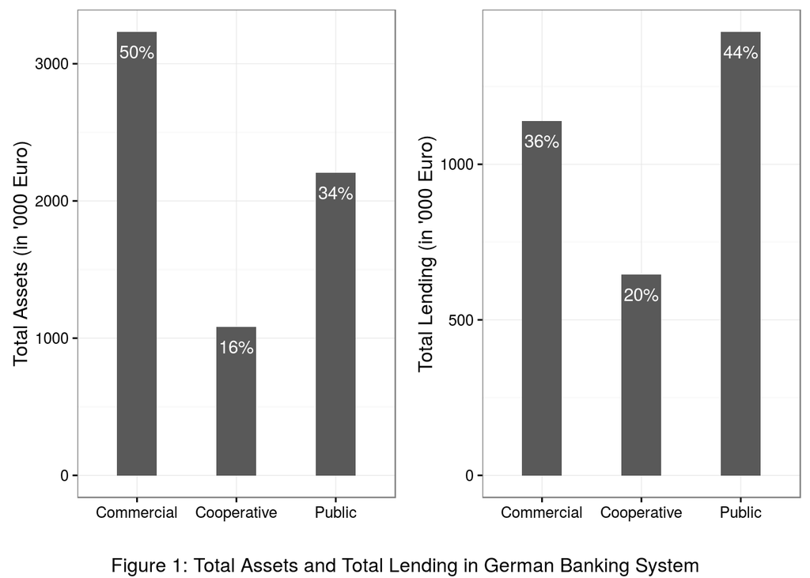

Public banks are particularly important in the German banking system with more than 400 public banks. Germany’s publicly owned savings banks (*Sparkassen*) are important local employers and lenders to small- and medium-sized enterprises; overall they account for 34% of total assets and 44% (see Figure 1) of total lending in Germany (Deutsche Bundesbank 2015). Hence, public savings banks constitute an essential element of the German banking sector and are important actors for the German *Mittelstand* economy.

At the same time, close links between savings banks and local politics make banks subject to potential political influence. *Sparkassen* are owned by German counties and municipalities, which grants local politicians access to key supervisions function in the bank management. Due to their public ownership, local politicians are members of savings banks’ Board of Directors (*Verwaltungsrat*) as well as the credit committee, which allows them to influence strategic decisions of savings banks (e.g. credit volume or bank consolidation) with direct implications for the municipal economy. Scholars, therefore, often speculate about the politicization of bank activities and political rent extraction by board members. Academic studies have shown that public banks are indeed subject to *political lending cycles* (Dinc 2005; Baum, Caglayan, and Talavera 2010; Jackowicz, Kowalewski, and Kozlowski 2012); recent papers have, moreover, demonstrated that German *Sparkassen* also follow the political business cycle of elections (Englmaier and Stowasser 2016; Gropp and Saadi 2015; Vins 2008).

### Effects for Elections?

Departing from this finding, our study aims to determine whether mayors with a seat at a savings bank board extract political rents in form of re-election from the board seat, i.e. it aims to understand if politicized lending behavior affects electoral outcomes. Incumbent parties and candidates seem to derive an advantage from holding political office during re-election campaigns (*incumbency advantage*) and previous research has demonstrated that also German politicians at the state, federal, and municipal political level enjoy incumbency advantages (Ade, Freier, and Odendahl 2014; Freier 2015; Hainmueller and Kern 2008). Our research project, therefore, contributes to both literatures - the *incumbency advantage* and the *political lending cycle* - by analyzing if politicized lending actually affects electoral performance of board members and, thus, if incumbents’ board membership is a mediating factor for the observed incumbency effect.

In our empirical strategy we exploit the fact that not all municipal mayors in Bavaria are members of a *Sparkassen* board and estimate if mayors with a board seat are more likely to get re-elected than mayors without a seat at the board.

## Findings

|  | not reelected | reelected |
| --- | --- | --- |
| non-board member | 182 (17%) | 866 (83%) |
| board-member | 41 (14%) | 252 (86%) |

Compared to mayors without a position in a Sparkassen board, mayors who are also represented in the governing board of the local savings bank have 3 percentage-point higher reelection rate.

[interactive chart not shown]

When we include the vote share a candidate received in the previous election along with board membership and whether or not a mayor was reelected (in the graph above), a much more fuzzy picture emerges. Most mayors who have done really good (>70% of votes) in the last election are reelected. On the other hand, most mayors who do not become reelected gained in between 50% and 70% of the votes in the last election.

However, it no clear patterns of board-member-mayors cluttering around the high numbers of approval in the previous election. Instead, mayors who are also board members seem scattered randomly throughout reelected and non-reelected mayors.

Guided by this first finding, we conducted a logistic regression to see whether a statistically significant effect remained when controlling for  
+ share of votes obtained during the last election + logged number of eligible voters in the municipality (as a proxy for municipality size) + sex of the mayoral candidate

**Logistic regression results w/ odds ratios**

|  | *Dependent variable:* |
| --- | --- |
|  | reelection of mayor |
| Sparkassen board member | 0.97 |
|  | p = 0.90 |
| Previous vote share | 1.05 |
|  | p = 0.0000*** |
| Female | 1.08 |
|  | p = 0.41 |
| Number eligible voters | 0.66 |
|  | p = 0.11 |
| Constant | 0.16 |
|  | p = 0.05** |
| Observations | 1,341 |
| Log Likelihood | -587.26 |
| *Note:* | p<0.1; p<0.05; p<0.01 |

Unfortunately, the logistic regression does not support the finding that there’s a statistically significant effect of board membership, as the p-value associated with our coefficient estimates are way too big. The same goes for all other, less specified models which we ran on the same data set (for a listing of all models which were run and further insights into the data, please see our [Research Paper](https://github.com/mberneaud/FinalProject/blob/master/paper/FinalPaper.pdf)).  
On a positive side, the regression shows a strong incumbency effect which is amplified the more votes a candidate received during the last election.

## Conclusion

At this stage of the research project, we can conclude that public banks are indeed heavily politicised. Moreover, the proportion of reelected mayors is slightly larger among those who are a member of their local *Sparkassen* board. Unfortunately, the logistic regression does not allow us to exclude the possibility that this relationship is due to random chance. In the future, data on additional German federal states must be collected in order to generate models with larger statistical power. These models might enable us to generate statistically significant results.

## References

Ade, Florian, Ronny Freier, and Christian Odendahl. 2014. “Incumbency, party identity and governmental lead: Evidence for heterogeneous incumbency effects for Germany.” *European Journal of Political Economy* vol.36 (no.3): 117–34. http://www.econstor.eu/handle/10419/61389.

Baum, Christopher F., Mustafa Caglayan, and Oleksandr Talavera. 2010. “Parliamentary election cycles and the Turkish banking sector.” *Journal of Banking and Finance* 34 (11): 2709–19. doi:10.1016/j.jbankfin.2010.05.013.

Deutsche Bundesbank. 2015. “Banking statistics 06/2015.” https://www.bundesbank.de/Redaktion/EN/Downloads/Publications/Statistical{\_}Supplement{\_}1/2015/2015{\_}06{\_}banking{\_}statistics.pdf?{\_}{\_}blob=publicationFile.

Dinc, Serdar. 2005. “Politicians and Banks: Political Influences on Government-Owned Banks in Emerging Markets.” *Journal of Financial Economics* vol. 77 (no. 2): 453–79.

Englmaier, Florian, and Till Stowasser. 2016. “Electoral Cycles in Savings Bank Lending.” *Journal of European Economic Association*, no. forthcoming.

Freier, Ronny. 2015. “The mayor’s advantage: Causal evidence on incumbency effects in German mayoral elections.” *European Journal of Political Economy* vol.40 (no.1): 16–30. http://www.econstor.eu/handle/10419/57258.

Gropp, Reint, and Vahid Saadi. 2015. “Electoral Credit Supply Cycles Among German Savings Banks.” *Leibnitz-Institut Für Wirtschaftsforschung Halle (IWH)//IWHOnline* 11/2015. Halle (Saale).

Hainmueller, Jens, and Holger Lutz Kern. 2008. “Incumbency as a source of spillover effects in mixed electoral systems: Evidence from a regression-discontinuity design.” *Electoral Studies* 27 (2): 213–27. doi:10.1016/j.electstud.2007.10.006.

Jackowicz, Krzysztof, Oskar Kowalewski, and Lukasz Kozlowski. 2012. “The influence of political factors on commercial banks in Central European Countries.” *Journal of Financial Stability* vol.9 (no.4): 759–77.

Vins, Oliver. 2008. “How Politics Influence State-owned Banks: The Case of German Savings Banks.” Edited by Goethe University Frankfurt. *Johann-Wolfgang-Goethe-Universität Frankfurt Am Main, Finance & Accounting//Working Paper Series* No. 191.

[^1]: The presented research project is part of a paper project by Guillermo Rosas (Washington University in St. Louis) and Jonas Markgraf (Hertie School of Governance Berlin).
[^2]: Spanish public savings banks (*cajas*) faltered and dissolved in the course of the bursting Spanish real estate bubble ([link](http://voxeu.org/article/five-lessons-spanish-cajas-debacle-new-euro-wide-supervisor)); similarly, German *Landesbanken* got into serious trouble and were partly consolidated ([link](http://www.sueddeutsche.de/geld/fehlspekulationen-der-landesbanken-chronologie-einer-krise-1.283250) (in German)). At the same time, German *Sparkassen* weathered the financial crisis well and emerged strengthened from it ([link](http://www.telegraph.co.uk/finance/financialcrisis/3190674/Financial-crisis-boosts-German-banks.html)). This heterogeneous crisis performance of public banks remains largely unexplained and motivates the PhD project of one of the authors.